# Project: Investigate a Dataset - [TMDB Movies]

- Introduction
- Data Wrangling
- Exploratory Data Analysis
- Conclusions

## Introduction

### Dataset Description

> The dataset contains information on movies collected from The Movie Database (TMDb), including user ratings and revenue. The dataset contains different columns that will be useful to the analysis, said columns include popularity, budget, revenue, title, director, genre, production company, release date, release year, vote average, budget and revenue. The dataset contains 10866 rows and 21 columns. The colums listed above will be used to answer the questins and pesent a thorough analysis of the dataset.

### Question(s) for Analysis

```python
#import statements for the package that will be used in tha analysis
import pandas as pd
import numpy as np
import matplotlib.pyplot as plt
import seaborn as sns
```

```python
# Upgrade pandas to use dataframe.explode() function.
!pip install --upgrade pandas==0.25.0
```

## Data Wrangling

```python
#uploading the dataset that will be used for the analysis
moviesdata = pd.read_csv("tmdbmovies.csv")
```

```python
#checking for the first rows of the dataset
moviesdata.head(10)
```

|  | id | imdb_id | popularity | budget | revenue | original_title | cast | homepage | director | tagline | ... | overview | runtime | genres | production_companies | release_date | vote_count | vote_average | release_year | budget_adj | revenue_adj |
| --- | --- | --- | --- | --- | --- | --- | --- | --- | --- | --- | --- | --- | --- | --- | --- | --- | --- | --- | --- | --- | --- |
| 0 | 135397 | tt0369610 | 32.985763 | 150000000 | 1513528810 | Jurassic World | Chris Pratt\|Bryce Dallas Howard\|Irrfan Khan\|Vi... | http://www.jurassicworld.com/ | Colin Trevorrow | The park is open. | ... | Twenty-two years after the events of Jurassic ... | 124 | Action\|Adventure\|Science Fiction\|Thriller | Universal Studios\|Amblin Entertainment\|Legenda... | 6/9/15 | 5562 | 6.5 | 2015 | 1.379999e+08 | 1.392446e+09 |
| 1 | 76341 | tt1392190 | 28.419936 | 150000000 | 378436354 | Mad Max: Fury Road | Tom Hardy\|Charlize Theron\|Hugh Keays-Byrne\|Nic... | http://www.madmaxmovie.com/ | George Miller | What a Lovely Day. | ... | An apocalyptic story set in the furthest reach... | 120 | Action\|Adventure\|Science Fiction\|Thriller | Village Roadshow Pictures\|Kennedy Miller Produ... | 5/13/15 | 6185 | 7.1 | 2015 | 1.379999e+08 | 3.481613e+08 |
| 2 | 262500 | tt2908446 | 13.112507 | 110000000 | 295238201 | Insurgent | Shailene Woodley\|Theo James\|Kate Winslet\|Ansel... | http://www.thedivergentseries.movie/#insurgent | Robert Schwentke | One Choice Can Destroy You | ... | Beatrice Prior must confront her inner demons ... | 119 | Adventure\|Science Fiction\|Thriller | Summit Entertainment\|Mandeville Films\|Red Wago... | 3/18/15 | 2480 | 6.3 | 2015 | 1.012000e+08 | 2.716190e+08 |
| 3 | 140607 | tt2488496 | 11.173104 | 200000000 | 2068178225 | Star Wars: The Force Awakens | Harrison Ford\|Mark Hamill\|Carrie Fisher\|Adam D... | http://www.starwars.com/films/star-wars-episod... | J.J. Abrams | Every generation has a story. | ... | Thirty years after defeating the Galactic Empi... | 136 | Action\|Adventure\|Science Fiction\|Fantasy | Lucasfilm\|Truenorth Productions\|Bad Robot | 12/15/15 | 5292 | 7.5 | 2015 | 1.839999e+08 | 1.902723e+09 |
| 4 | 168259 | tt2820852 | 9.335014 | 190000000 | 1506249360 | Furious 7 | Vin Diesel\|Paul Walker\|Jason Statham\|Michelle ... | http://www.furious7.com/ | James Wan | Vengeance Hits Home | ... | Deckard Shaw seeks revenge against Dominic Tor... | 137 | Action\|Crime\|Thriller | Universal Pictures\|Original Film\|Media Rights ... | 4/1/15 | 2947 | 7.3 | 2015 | 1.747999e+08 | 1.385749e+09 |
| 5 | 281957 | tt1663202 | 9.110700 | 135000000 | 532950503 | The Revenant | Leonardo DiCaprio\|Tom Hardy\|Will Poulter\|Domhn... | http://www.foxmovies.com/movies/the-revenant | Alejandro González Iñárritu | (n. One who has returned, as if from the dead.) | ... | In the 1820s, a frontiersman, Hugh Glass, sets... | 156 | Western\|Drama\|Adventure\|Thriller | Regency Enterprises\|Appian Way\|CatchPlay\|Anony... | 12/25/15 | 3929 | 7.2 | 2015 | 1.241999e+08 | 4.903142e+08 |
| 6 | 87101 | tt1340138 | 8.654359 | 155000000 | 440603537 | Terminator Genisys | Arnold Schwarzenegger\|Jason Clarke\|Emilia Clar... | http://www.terminatormovie.com/ | Alan Taylor | Reset the future | ... | The year is 2029. John Connor, leader of the r... | 125 | Science Fiction\|Action\|Thriller\|Adventure | Paramount Pictures\|Skydance Productions | 6/23/15 | 2598 | 5.8 | 2015 | 1.425999e+08 | 4.053551e+08 |
| 7 | 286217 | tt3659388 | 7.667400 | 108000000 | 595380321 | The Martian | Matt Damon\|Jessica Chastain\|Kristen Wiig\|Jeff ... | http://www.foxmovies.com/movies/the-martian | Ridley Scott | Bring Him Home | ... | During a manned mission to Mars, Astronaut Mar... | 141 | Drama\|Adventure\|Science Fiction | Twentieth Century Fox Film Corporation\|Scott F... | 9/30/15 | 4572 | 7.6 | 2015 | 9.935996e+07 | 5.477497e+08 |
| 8 | 211672 | tt2293640 | 7.404165 | 74000000 | 1156730962 | Minions | Sandra Bullock\|Jon Hamm\|Michael Keaton\|Allison... | http://www.minionsmovie.com/ | Kyle Balda\|Pierre Coffin | Before Gru, they had a history of bad bosses | ... | Minions Stuart, Kevin and Bob are recruited by... | 91 | Family\|Animation\|Adventure\|Comedy | Universal Pictures\|Illumination Entertainment | 6/17/15 | 2893 | 6.5 | 2015 | 6.807997e+07 | 1.064192e+09 |
| 9 | 150540 | tt2096673 | 6.326804 | 175000000 | 853708609 | Inside Out | Amy Poehler\|Phyllis Smith\|Richard Kind\|Bill Ha... | http://movies.disney.com/inside-out | Pete Docter | Meet the little voices inside your head. | ... | Growing up can be a bumpy road, and it's no ex... | 94 | Comedy\|Animation\|Family | Walt Disney Pictures\|Pixar Animation Studios\|W... | 6/9/15 | 3935 | 8.0 | 2015 | 1.609999e+08 | 7.854116e+08 |

10 rows × 21 columns

```python
#check the last rows of the dataset which will help check which is the last entry
moviesdata.tail(10)
```

|  | id | imdb_id | popularity | budget | revenue | original_title | cast | homepage | director | tagline | ... | overview | runtime | genres | production_companies | release_date | vote_count | vote_average | release_year | budget_adj | revenue_adj |
| --- | --- | --- | --- | --- | --- | --- | --- | --- | --- | --- | --- | --- | --- | --- | --- | --- | --- | --- | --- | --- | --- |
| 10856 | 20277 | tt0061135 | 0.140934 | 0 | 0 | The Ugly Dachshund | Dean Jones\|Suzanne Pleshette\|Charles Ruggles\|K... | NaN | Norman Tokar | A HAPPY HONEYMOON GOES TO THE DOGS!...When a G... | ... | The Garrisons (Dean Jones and Suzanne Pleshett... | 93 | Comedy\|Drama\|Family | Walt Disney Pictures | 2/16/66 | 14 | 5.7 | 1966 | 0.000000 | 0.0 |
| 10857 | 5921 | tt0060748 | 0.131378 | 0 | 0 | Nevada Smith | Steve McQueen\|Karl Malden\|Brian Keith\|Arthur K... | NaN | Henry Hathaway | Some called him savage- and some called him sa... | ... | Nevada Smith is the young son of an Indian mot... | 128 | Action\|Western | Paramount Pictures\|Solar Productions\|Embassy P... | 6/10/66 | 10 | 5.9 | 1966 | 0.000000 | 0.0 |
| 10858 | 31918 | tt0060921 | 0.317824 | 0 | 0 | The Russians Are Coming, The Russians Are Coming | Carl Reiner\|Eva Marie Saint\|Alan Arkin\|Brian K... | NaN | Norman Jewison | IT'S A PLOT! ...to make the world die laughing!! | ... | Without hostile intent, a Soviet sub runs agro... | 126 | Comedy\|War | The Mirisch Corporation | 5/25/66 | 11 | 5.5 | 1966 | 0.000000 | 0.0 |
| 10859 | 20620 | tt0060955 | 0.089072 | 0 | 0 | Seconds | Rock Hudson\|Salome Jens\|John Randolph\|Will Gee... | NaN | John Frankenheimer | NaN | ... | A secret organisation offers wealthy people a ... | 100 | Mystery\|Science Fiction\|Thriller\|Drama | Gibraltar Productions\|Joel Productions\|John Fr... | 10/5/66 | 22 | 6.6 | 1966 | 0.000000 | 0.0 |
| 10860 | 5060 | tt0060214 | 0.087034 | 0 | 0 | Carry On Screaming! | Kenneth Williams\|Jim Dale\|Harry H. Corbett\|Joa... | NaN | Gerald Thomas | Carry On Screaming with the Hilarious CARRY ON... | ... | The sinister Dr Watt has an evil scheme going.... | 87 | Comedy | Peter Rogers Productions\|Anglo-Amalgamated Fil... | 5/20/66 | 13 | 7.0 | 1966 | 0.000000 | 0.0 |
| 10861 | 21 | tt0060371 | 0.080598 | 0 | 0 | The Endless Summer | Michael Hynson\|Robert August\|Lord 'Tally Ho' B... | NaN | Bruce Brown | NaN | ... | The Endless Summer, by Bruce Brown, is one of ... | 95 | Documentary | Bruce Brown Films | 6/15/66 | 11 | 7.4 | 1966 | 0.000000 | 0.0 |
| 10862 | 20379 | tt0060472 | 0.065543 | 0 | 0 | Grand Prix | James Garner\|Eva Marie Saint\|Yves Montand\|Tosh... | NaN | John Frankenheimer | Cinerama sweeps YOU into a drama of speed and ... | ... | Grand Prix driver Pete Aron is fired by his te... | 176 | Action\|Adventure\|Drama | Cherokee Productions\|Joel Productions\|Douglas ... | 12/21/66 | 20 | 5.7 | 1966 | 0.000000 | 0.0 |
| 10863 | 39768 | tt0060161 | 0.065141 | 0 | 0 | Beregis Avtomobilya | Innokentiy Smoktunovskiy\|Oleg Efremov\|Georgi Z... | NaN | Eldar Ryazanov | NaN | ... | An insurance agent who moonlights as a carthie... | 94 | Mystery\|Comedy | Mosfilm | 1/1/66 | 11 | 6.5 | 1966 | 0.000000 | 0.0 |
| 10864 | 21449 | tt0061177 | 0.064317 | 0 | 0 | What's Up, Tiger Lily? | Tatsuya Mihashi\|Akiko Wakabayashi\|Mie Hama\|Joh... | NaN | Woody Allen | WOODY ALLEN STRIKES BACK! | ... | In comic Woody Allen's film debut, he took the... | 80 | Action\|Comedy | Benedict Pictures Corp. | 11/2/66 | 22 | 5.4 | 1966 | 0.000000 | 0.0 |
| 10865 | 22293 | tt0060666 | 0.035919 | 19000 | 0 | Manos: The Hands of Fate | Harold P. Warren\|Tom Neyman\|John Reynolds\|Dian... | NaN | Harold P. Warren | It's Shocking! It's Beyond Your Imagination! | ... | A family gets lost on the road and stumbles up... | 74 | Horror | Norm-Iris | 11/15/66 | 15 | 1.5 | 1966 | 127642.279154 | 0.0 |

10 rows × 21 columns

```python
#checking the shape of the dataset to find the nuber of rows and columns
moviesdata.shape
```

```
(10866, 21)
```

```python
#check the information about the dataset, the datatypes ad others
moviesdata.info()
```

```
<class 'pandas.core.frame.DataFrame'>
RangeIndex: 10866 entries, 0 to 10865
Data columns (total 21 columns):
 #   Column                Non-Null Count  Dtype
---  ------                --------------  -----
 0   id                    10866 non-null  int64
 1   imdb_id               10856 non-null  object
 2   popularity            10866 non-null  float64
 3   budget                10866 non-null  int64
 4   revenue               10866 non-null  int64
 5   original_title        10866 non-null  object
 6   cast                  10790 non-null  object
 7   homepage              2936 non-null   object
 8   director              10822 non-null  object
 9   tagline               8042 non-null   object
 10  keywords              9373 non-null   object
 11  overview              10862 non-null  object
 12  runtime               10866 non-null  int64
 13  genres                10843 non-null  object
 14  production_companies  9836 non-null   object
 15  release_date          10866 non-null  object
 16  vote_count            10866 non-null  int64
 17  vote_average          10866 non-null  float64
 18  release_year          10866 non-null  int64
 19  budget_adj            10866 non-null  float64
 20  revenue_adj           10866 non-null  float64
dtypes: float64(4), int64(6), object(11)
memory usage: 1.7+ MB
```

```python
#checking the missing values in the dataset
moviesdata.isnull().sum()
```

```
id                         0
imdb_id                   10
popularity                 0
budget                     0
revenue                    0
original_title             0
cast                      76
homepage                7930
director                  44
tagline                 2824
keywords                1493
overview                   4
runtime                    0
genres                    23
production_companies    1030
release_date               0
vote_count                 0
vote_average               0
release_year               0
budget_adj                 0
revenue_adj                0
dtype: int64
```

```python
#get the percentage of missing values to see if they can be dropped or filled with mean.
moviesdata.isnull().sum() * 100/len(moviesdata)
```

```
id                       0.000000
imdb_id                  0.092030
popularity               0.000000
budget                   0.000000
revenue                  0.000000
original_title           0.000000
cast                     0.699429
homepage                72.979937
director                 0.404933
tagline                 25.989324
keywords                13.740107
overview                 0.036812
runtime                  0.000000
genres                   0.211669
production_companies     9.479109
release_date             0.000000
vote_count               0.000000
vote_average             0.000000
release_year             0.000000
budget_adj               0.000000
revenue_adj              0.000000
dtype: float64
```

From that analysis, missing values with the highest percentage are in columns that may be dropped since they will not be used in the analysis and for the production_companies, those missing values may be dropped as they are less than ten percent.

```python
#drop columns
moviesdata.drop(columns=['imdb_id', 'cast','homepage', 'tagline','runtime', 'keywords', 'overview', 'budget_adj', 'revenue_adj'], inplace = True)
```

```python
#drop null values
moviesdata.dropna(inplace = True)
moviesdata.isnull().sum()
```

```
id                      0
popularity              0
budget                  0
revenue                 0
original_title          0
director                0
genres                  0
production_companies    0
release_date            0
vote_count              0
vote_average            0
release_year            0
dtype: int64
```

```python
#check duplicate values
moviesdata.duplicated().sum()
```

```
1
```

```python
#drop duplicate values
moviesdata.drop_duplicates(inplace = True)
moviesdata.duplicated().sum()
```

```
0
```

Having removed the duplicates, null values, and dropped unnecessary columns, the data is ready for cleaning.

### Data Cleaning

> In this step, changing data types to ones that I can work with.

```python
#check the data type of the dataset
moviesdata.dtypes
```

```
id                        int64
popularity              float64
budget                    int64
revenue                   int64
original_title           object
director                 object
genres                   object
production_companies     object
release_date             object
vote_count                int64
vote_average            float64
release_year              int64
dtype: object
```

From the dataypes release date needs to be changed to the datetime format.

```python
#change the release_date to a datetime format
moviesdata['release_date'] = pd.to_datetime(moviesdata['release_date'])
#check to see if it has worked
moviesdata.dtypes
```

```
id                               int64
popularity                     float64
budget                           int64
revenue                          int64
original_title                  object
director                        object
genres                          object
production_companies            object
release_date            datetime64[ns]
vote_count                       int64
vote_average                   float64
release_year                     int64
dtype: object
```

Create a profits colums since most of the questions require that data

```python
#find the profit and create a column
moviesdata['profits'] = moviesdata.revenue - moviesdata.budget

#check to see if it was created
moviesdata.head()
```

|  | id | popularity | budget | revenue | original_title | director | genres | production_companies | release_date | vote_count | vote_average | release_year | profits |
| --- | --- | --- | --- | --- | --- | --- | --- | --- | --- | --- | --- | --- | --- |
| 0 | 135397 | 32.985763 | 150000000 | 1513528810 | Jurassic World | Colin Trevorrow | Action\|Adventure\|Science Fiction\|Thriller | Universal Studios\|Amblin Entertainment\|Legenda... | 2015-06-09 | 5562 | 6.5 | 2015 | 1363528810 |
| 1 | 76341 | 28.419936 | 150000000 | 378436354 | Mad Max: Fury Road | George Miller | Action\|Adventure\|Science Fiction\|Thriller | Village Roadshow Pictures\|Kennedy Miller Produ... | 2015-05-13 | 6185 | 7.1 | 2015 | 228436354 |
| 2 | 262500 | 13.112507 | 110000000 | 295238201 | Insurgent | Robert Schwentke | Adventure\|Science Fiction\|Thriller | Summit Entertainment\|Mandeville Films\|Red Wago... | 2015-03-18 | 2480 | 6.3 | 2015 | 185238201 |
| 3 | 140607 | 11.173104 | 200000000 | 2068178225 | Star Wars: The Force Awakens | J.J. Abrams | Action\|Adventure\|Science Fiction\|Fantasy | Lucasfilm\|Truenorth Productions\|Bad Robot | 2015-12-15 | 5292 | 7.5 | 2015 | 1868178225 |
| 4 | 168259 | 9.335014 | 190000000 | 1506249360 | Furious 7 | James Wan | Action\|Crime\|Thriller | Universal Pictures\|Original Film\|Media Rights ... | 2015-04-01 | 2947 | 7.3 | 2015 | 1316249360 |

```python
#describe the data
moviesdata.describe()
```

|  | id | popularity | budget | revenue | vote_count | vote_average | release_year | profits |
| --- | --- | --- | --- | --- | --- | --- | --- | --- |
| count | 9806.000000 | 9806.000000 | 9.806000e+03 | 9.806000e+03 | 9806.000000 | 9806.000000 | 9806.000000 | 9.806000e+03 |
| mean | 63287.653783 | 0.693143 | 1.612525e+07 | 4.407785e+07 | 238.622578 | 5.966459 | 2000.890271 | 2.795260e+07 |
| std | 90808.473021 | 1.035525 | 3.216819e+07 | 1.224038e+08 | 602.081472 | 0.914291 | 13.032372 | 1.012824e+08 |
| min | 5.000000 | 0.000188 | 0.000000e+00 | 0.000000e+00 | 10.000000 | 1.500000 | 1960.000000 | -4.139124e+08 |
| 25% | 10247.500000 | 0.231581 | 0.000000e+00 | 0.000000e+00 | 18.000000 | 5.400000 | 1994.000000 | 0.000000e+00 |
| 50% | 18725.500000 | 0.418756 | 1.403930e+05 | 0.000000e+00 | 46.000000 | 6.000000 | 2005.000000 | 0.000000e+00 |
| 75% | 70586.750000 | 0.774231 | 1.900000e+07 | 3.064621e+07 | 172.000000 | 6.600000 | 2011.000000 | 1.409774e+07 |
| max | 417859.000000 | 32.985763 | 4.250000e+08 | 2.781506e+09 | 9767.000000 | 8.700000 | 2015.000000 | 2.544506e+09 |

## Exploratory Data Analysis

### Question 1: Which year has the highest average votes?

```python
moviesdata.columns
```

```
Index(['id', 'popularity', 'budget', 'revenue', 'original_title', 'director',
       'genres', 'production_companies', 'release_date', 'vote_count',
       'vote_average', 'release_year', 'profits'],
      dtype='object')
```

```python
#check for the highest average votes
moviesdata.vote_average.max()
```

```
8.7
```

```python
#the question wants to display the year
moviesdata[moviesdata['vote_average']>=8.7]['release_year']
```

```
6911    2006
Name: release_year, dtype: int64
```

```python
#check for popluriry to compare if by having alot of vote average means you are the most popular.
pop_movies = moviesdata.popularity.max()
```

```python
moviesdata[moviesdata['popularity']>=pop_movies]['release_year']
```

```
0    2015
Name: release_year, dtype: int64
```

```python
#check the maximum profits earned by the movies
max_profit = moviesdata.profits.max()
```

```python
moviesdata[moviesdata['profits']>=max_profit]['release_year']
```

```
1386    2009
Name: release_year, dtype: int64
```

### Question 3 How many movies are made per year?

```python
#It is important to run this so as to get the columns names correctly.
moviesdata.columns
```

```
Index(['id', 'popularity', 'budget', 'revenue', 'original_title', 'director',
       'genres', 'production_companies', 'release_date', 'vote_count',
       'vote_average', 'release_year', 'profits'],
      dtype='object')
```

```python
#solve the question
moviesperyear= moviesdata['release_year'].value_counts()
moviesperyear
```

```
2014    638
2013    568
2015    561
2012    500
2009    474
2011    461
2008    443
2010    421
2007    392
2006    353
2005    324
2003    254
2004    253
2002    243
2001    212
```

[output cut: 42 more lines]

### Question 4 Which movie is the most popular and which are the top ten most popular?

The question seeks to find out of all the movies made for all those years, which is the most popular and which are the top ten most popular.

```python
moviesdata.columns
```

```
Index(['id', 'popularity', 'budget', 'revenue', 'original_title', 'director',
       'genres', 'production_companies', 'release_date', 'vote_count',
       'vote_average', 'release_year', 'profits'],
      dtype='object')
```

```python
#In question one, I had already ran the most popular average which was stored in the variable `pop_movies`.
#Using that variable, I will run the most popular movie by name.
moviesdata[moviesdata['popularity']>=pop_movies]['original_title']
```

```
0    Jurassic World
Name: original_title, dtype: object
```

```python
#find the top ten most popular movies and the years they were released
top_ten=moviesdata.nlargest(10, 'popularity')[['original_title', 'release_year']]\
.set_index('release_year')
top_ten
```

| release_year | original_title |
| --- | --- |
| 2015 | Jurassic World |
| 2015 | Mad Max: Fury Road |
| 2014 | Interstellar |
| 2014 | Guardians of the Galaxy |
| 2015 | Insurgent |
| 2014 | Captain America: The Winter Soldier |
| 1977 | Star Wars |
| 2014 | John Wick |
| 2015 | Star Wars: The Force Awakens |
| 2014 | The Hunger Games: Mockingjay - Part 1 |

The most popular movie is Jurrastic world whih was made in 2015 and also shows the other nine top movies.

### Question 5 Which are the top ten movies with the highest revenue?

```python
top_ten_rev= moviesdata.nlargest(10, 'revenue')[['original_title', 'release_year','revenue']]\
.set_index('release_year')
top_ten_rev
```

| release_year | original_title | revenue |
| --- | --- | --- |
| 2009 | Avatar | 2781505847 |
| 2015 | Star Wars: The Force Awakens | 2068178225 |
| 1997 | Titanic | 1845034188 |
| 2012 | The Avengers | 1519557910 |
| 2015 | Jurassic World | 1513528810 |
| 2015 | Furious 7 | 1506249360 |
| 2015 | Avengers: Age of Ultron | 1405035767 |
| 2011 | Harry Potter and the Deathly Hallows: Part 2 | 1327817822 |
| 2013 | Frozen | 1274219009 |
| 2013 | Iron Man 3 | 1215439994 |

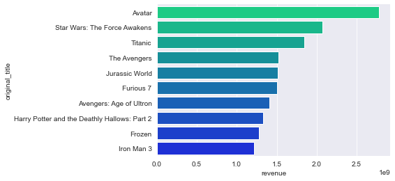

```python
#visualize the data
sns.set_style('darkgrid')
sns.set_palette('Set2')
sns.barplot(x='revenue', y = 'original_title', data = top_ten_rev,palette="winter_r", dodge = False);
sns.despine()
```

### Question 6 Which movies are the top ten highest rated and who are the directors?

```python
moviesdata.columns
```

```
Index(['id', 'popularity', 'budget', 'revenue', 'original_title', 'director',
       'genres', 'production_companies', 'release_date', 'vote_count',
       'vote_average', 'release_year', 'profits'],
      dtype='object')
```

```python
topten_voteavg= moviesdata.nlargest(10, 'vote_average')[['original_title', 'director', 'vote_average']]\
.set_index('director')
topten_voteavg
```

| director | original_title | vote_average |
| --- | --- | --- |
| David Mallet | Pink Floyd: Pulse | 8.7 |
| Curt Morgan | The Art of Flight | 8.5 |
| Martin Scorsese\|Michael Henry Wilson | A Personal Journey with Martin Scorsese Throug... | 8.5 |
| Saul Swimmer | Queen - Rock Montreal | 8.5 |
| Andrew Jarecki | The Jinx: The Life and Deaths of Robert Durst | 8.4 |
| Frank Darabont | The Shawshank Redemption | 8.4 |
| Jorge Ramírez Suárez | Guten Tag, Ramón | 8.4 |
| Jonathan Demme | Stop Making Sense | 8.4 |
| Paul Dugdale | One Direction: Where We Are - The Concert | 8.3 |
| Sam Dunn\|Scot McFadyen | Iron Maiden: Flight 666 | 8.3 |

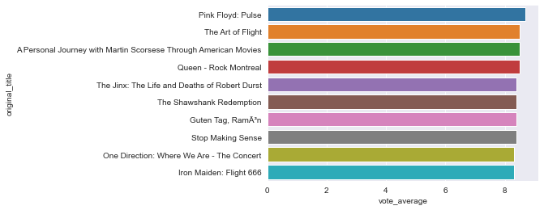

```python
sns.set_style('darkgrid')
sns.set_palette('Set2')
sns.barplot(x='vote_average',y='original_title', data = topten_voteavg, dodge = False, palette="tab10");
```

## Question 7 Who are the top ten most popular directors and which movies did they direct?

```python
moviesdata.columns
```

```
Index(['id', 'popularity', 'budget', 'revenue', 'original_title', 'director',
       'genres', 'production_companies', 'release_date', 'vote_count',
       'vote_average', 'release_year', 'profits'],
      dtype='object')
```

```python
popular_directors= moviesdata.nlargest(10, 'popularity')[['director','original_title', 'genres']]\
.set_index('director')
popular_directors
```

| director | original_title | genres |
| --- | --- | --- |
| Colin Trevorrow | Jurassic World | Action\|Adventure\|Science Fiction\|Thriller |
| George Miller | Mad Max: Fury Road | Action\|Adventure\|Science Fiction\|Thriller |
| Christopher Nolan | Interstellar | Adventure\|Drama\|Science Fiction |
| James Gunn | Guardians of the Galaxy | Action\|Science Fiction\|Adventure |
| Robert Schwentke | Insurgent | Adventure\|Science Fiction\|Thriller |
| Joe Russo\|Anthony Russo | Captain America: The Winter Soldier | Action\|Adventure\|Science Fiction |
| George Lucas | Star Wars | Adventure\|Action\|Science Fiction |
| Chad Stahelski\|David Leitch | John Wick | Action\|Thriller |
| J.J. Abrams | Star Wars: The Force Awakens | Action\|Adventure\|Science Fiction\|Fantasy |
| Francis Lawrence | The Hunger Games: Mockingjay - Part 1 | Science Fiction\|Adventure\|Thriller |

## Question 8 Does popularity and vote average affect the revenue of the movies?

```python
moviesdata.columns
```

```
Index(['id', 'popularity', 'budget', 'revenue', 'original_title', 'director',
       'genres', 'production_companies', 'release_date', 'vote_count',
       'vote_average', 'release_year', 'profits'],
      dtype='object')
```

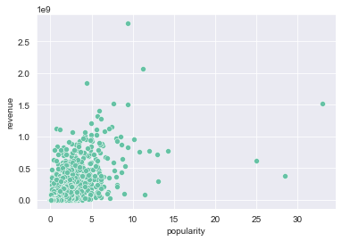

```python
#for this question we need to create a scatter plot of the two.
#the first plot os for popularity and revenue
sns.scatterplot(x='popularity', y='revenue', data = moviesdata)
```

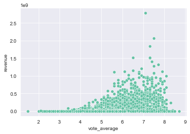

```python
#this plot is for vote_average and revenue
sns.scatterplot(x='vote_average', y='revenue', data = moviesdata)
```

The scatterplot shows that popularity does affect revenue. Low popularity shows less revenues from the movies.

# Question 9 Which are the top ten production companies based on the number of movies they have produced?

```python
moviesdata.columns
```

```
Index(['id', 'popularity', 'budget', 'revenue', 'original_title', 'director',
       'genres', 'production_companies', 'release_date', 'vote_count',
       'vote_average', 'release_year', 'profits'],
      dtype='object')
```

```python
movies_counts = moviesdata['production_companies'].value_counts()
movies_counts
```

```
Paramount Pictures                                   156
Universal Pictures                                   133
Warner Bros.                                          84
Walt Disney Pictures                                  75
Columbia Pictures                                     72
                                                    ...
Harvey Mason Media                                     1
Eskwad|StudioCanal|Wild Bunch|Canal+|CinÃ©CinÃ©ma      1
Walt Disney Pictures|Disney Channel                    1
Silverwood Films                                       1
Norm-Iris                                              1
Name: production_companies, Length: 7423, dtype: int64
```

```python
topcompany=movies_counts.head(10)
topcompany
```

```
Paramount Pictures                        156
Universal Pictures                        133
Warner Bros.                               84
Walt Disney Pictures                       75
Columbia Pictures                          72
Metro-Goldwyn-Mayer (MGM)                  72
New Line Cinema                            61
Touchstone Pictures                        51
20th Century Fox                           50
Twentieth Century Fox Film Corporation     49
Name: production_companies, dtype: int64
```

From the analysis, the data shows that the top production company with the most number of movies Paramount pictures

# Question 10 Top ten most profitable production companies.

```python
moviesdata.columns
```

```
Index(['id', 'popularity', 'budget', 'revenue', 'original_title', 'director',
       'genres', 'production_companies', 'release_date', 'vote_count',
       'vote_average', 'release_year', 'profits'],
      dtype='object')
```

```python
prof_companies= moviesdata.nlargest(10, 'profits')[['production_companies', 'profits','genres']]\
.set_index('profits')
prof_companies
```

| profits | production_companies | genres |
| --- | --- | --- |
| 2544505847 | Ingenious Film Partners\|Twentieth Century Fox ... | Action\|Adventure\|Fantasy\|Science Fiction |
| 1868178225 | Lucasfilm\|Truenorth Productions\|Bad Robot | Action\|Adventure\|Science Fiction\|Fantasy |
| 1645034188 | Paramount Pictures\|Twentieth Century Fox Film ... | Drama\|Romance\|Thriller |
| 1363528810 | Universal Studios\|Amblin Entertainment\|Legenda... | Action\|Adventure\|Science Fiction\|Thriller |
| 1316249360 | Universal Pictures\|Original Film\|Media Rights ... | Action\|Crime\|Thriller |
| 1299557910 | Marvel Studios | Science Fiction\|Action\|Adventure |
| 1202817822 | Warner Bros.\|Heyday Films\|Moving Picture Compa... | Adventure\|Family\|Fantasy |
| 1125035767 | Marvel Studios\|Prime Focus\|Revolution Sun Studios | Action\|Adventure\|Science Fiction |
| 1124219009 | Walt Disney Pictures\|Walt Disney Animation Stu... | Animation\|Adventure\|Family |
| 1084279658 | Columbia Pictures | Crime\|Drama\|Mystery\|Thriller\|Action |

# Question 11 Which are the top ten most commercially succesful years in movie production

```python
succesful_years = moviesdata.nlargest(10, 'revenue')[['revenue', 'release_date', 'release_year']]\
.set_index('release_year')
succesful_years
```

| release_year | revenue | release_date |
| --- | --- | --- |
| 2009 | 2781505847 | 2009-12-10 |
| 2015 | 2068178225 | 2015-12-15 |
| 1997 | 1845034188 | 1997-11-18 |
| 2012 | 1519557910 | 2012-04-25 |
| 2015 | 1513528810 | 2015-06-09 |
| 2015 | 1506249360 | 2015-04-01 |
| 2015 | 1405035767 | 2015-04-22 |
| 2011 | 1327817822 | 2011-07-07 |
| 2013 | 1274219009 | 2013-11-27 |
| 2013 | 1215439994 | 2013-04-18 |

## Conclusions

> The questions were a great way to analyze the data and get to understand it even more. From my analysis I have made a few conclusions which are going to be analysed in this section.

> 2014 had the most number of movies made of all the years and 1969 had the least number of movies made. The analysis showed that the number of movies made each year has increased since 1969 and following that trend the numbers ae sure to increase.

> The highest rated top ten movies was also an interesting analysis as the top ten highest rated movies none of them made it as the top ten commercially succesfull movies proving that best ratings do not equal profits.

> On director popularity, **Colin Trevorrow** is the most popular based on the movie **Jurrasic World** and the genres vary. **Paramount Pictures** has produced the most movies over the years yet it is not the most profitable production company showing that a prpduction company is not necessarity bring in alot of revenue based on the number of moves they have done.

## Limitations

> The dataset had a lot of null values.

## Resources

> https://stackoverflow.com/questions/22219004/how-to-group-dataframe-rows-into-list-in-pandas-groupby https://indianaiproduction.com/seaborn-scatter-plot/ https://machinelearningknowledge.ai/seaborn-bar-plot-with-sns-barplot-examples-for-beginners/ https://stackoverflow.com/questions/43178137/how-do-i-plot-a-bar-graph-using-pandas https://pythonspot.com/pandas-groupby/ https://book4you.org/book/3367370/62327b

```python
from subprocess import call
call(['python', '-m', 'nbconvert', 'Investigate_a_Dataset.ipynb'])
```

```
4294967295
```